2024/25

# Spielplan

[zur Übersicht](https://oper-frankfurt.de/de/spielplan/)

[video not shown]

[figure not shown]

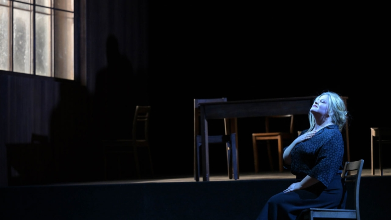

Marigona Qerkezi (Norma)  
© Barbara Aumüller

[video not shown]

[figure not shown]

## Norma

#### Vincenzo Bellini 1801–1835

Tragedia lirica in zwei Akten  
Text von Felice Romani nach Alexandre Soumet  
Uraufführung 1831

Premiere vom 10. Juni 2018  
In italienischer Sprache mit deutschen und englischen Übertiteln

**Einführungen eine halbe Stunde vor Vorstellungsbeginn im Holzfoyer und als Audioeinführung überall, wo es Podcasts gibt. Weitere spannende Inhalte zur Produktion finden Sie im [Opernappetizer](https://blog.oper-frankfurt.de/blog/norma) auf unserem Blog.**

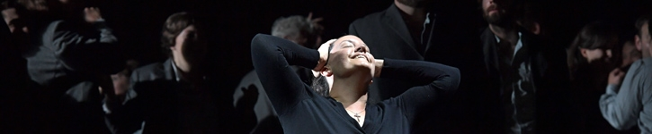

Förmlich mit ihrer Partie verwachsen scheint Sängerin Marigona Qerkezi. Plastisch profiliert die dramatische Sopranistin die Titelgestalt von Bellinis *Norma*, vermag im Laufe des Geschehens auf der Bühne der Frankfurter Oper ihre Präsenz sängerisch und schauspielerisch sogar noch zu intensivieren.  
Dass sie souverän alle Herausforderungen an stimmliches und gestalterisches Vermögen meistert, hinterließ bei der Wiederaufnahme tiefe Eindrücke. Mehr noch, dass sie sich regelrecht die Seele aus dem Leib sang, je auswegloser sich die Lage entwickelte, imponierte außerordentlich. (…)  
*Ulrich Boller, Frankfurter Neue Presse*

Während die Erwachsenen in der Vorstellung sitzen, bekommen Kinder von 3–8 Jahren im Ballettsaal ein abwechslungsreiches Programm rund um die jeweilige Oper geboten. Die Betreuung ist kostenlos, die Anzahl der Plätze ist begrenzt.

Anmeldung unter: gaesteservice@buehnen-frankfurt.de oder 069 212 37 348 (bitte Rückrufnummer angeben).

Vincenzo Bellini war der Überzeugung, die Oper müsse durch ihren Gesang »weinen, schaudern und sterben machen«. Mit seiner Partitur der *Norma* kam er diesem Ideal so nahe wie nie zuvor. Belcanto in seiner schönsten Form verbindet sich darin mit der Charakterstudie einer zurückgewiesenen Frau. Die gallische Seherin Norma liebt den verfeindeten römischen Prokonsul Pollione. Als dieser sie jedoch mit der jüngeren Adalgisa betrügt, verfällt sie in Raserei. Normas emotionales Wechselbad mündet schließlich in ein heroisches Selbstopfer an der Seite ihres Geliebten. Wurde Bellinis Oper lange Zeit primär als musikalisch kostbares Diven-Stück angesehen, so rückt in den vergangenen Jahren zunehmend ihr dramatischer Gehalt ins Bewusstsein. Christof Loy lotet in seiner Inszenierung die psychologischen Zwischentöne des Werkes aus und schafft ein packendes Kammerspiel, das im Verbund mit Bellinis Musik unmittelbar zu Herzen geht.

Apr 2025

[So20.](https://oper-frankfurt.de/de/spielplan/norma_4/?id_datum=4109#date) So27.

Mai 2025

[Sa03.](https://oper-frankfurt.de/de/spielplan/norma_4/?id_datum=4111#date) [Fr09.](https://oper-frankfurt.de/de/spielplan/norma_4/?id_datum=4112#date) [So11.](https://oper-frankfurt.de/de/spielplan/norma_4/?id_datum=4113#date) [Do15.](https://oper-frankfurt.de/de/spielplan/norma_4/?id_datum=4114#date) [Sa17.](https://oper-frankfurt.de/de/spielplan/norma_4/?id_datum=4115#date) [Fr23.](https://oper-frankfurt.de/de/spielplan/norma_4/?id_datum=4116#date) [Sa31.](https://oper-frankfurt.de/de/spielplan/norma_4/?id_datum=4117#date)

[Tickets](https://oper-frankfurt.eventim-inhouse.de/webshop/webticket/shop?event=14354&languages=de)

## Ihre Auswahl

Oper für Familien

Mit Kinderbetreuung

**Sonntag**

27. April 2025

**Beginn**

15.30 Uhr

**Dauer**

ca. 3 Std. inkl. 1 Pause nach ca. 1 Std. 20 Min.

**Ort**

Opernhaus

**Abonnement**

Serie 17

**Preise**

A

## Besetzung

**Musikalische Leitung**

[Giuliano Carella](https://oper-frankfurt.de/de/ensemble-gaeste-teams/dirigenten/?detail=295)

**Inszenierung**

[Christof Loy](https://oper-frankfurt.de/de/ensemble-gaeste-teams/regie/?detail=111)

**Szenische Leitung der Wiederaufnahme**

[Aileen Schneider](https://oper-frankfurt.de/de/ensemble-gaeste-teams/regie/?detail=1087)

**Bühnenbild**

[Raimund Orfeo Voigt](https://oper-frankfurt.de/de/ensemble-gaeste-teams/regie/?detail=586)

**Kostüme**

[Ursula Renzenbrink](https://oper-frankfurt.de/de/ensemble-gaeste-teams/regie/?detail=170)

**Licht**

[Olaf Winter](https://oper-frankfurt.de/de/ensemble-gaeste-teams/regie/?detail=28)

**Chor**

[Álvaro Corral Matute](https://oper-frankfurt.de/de/ensemble-gaeste-teams/regie/?detail=1162)

**Dramaturgie**

[Konrad Kuhn](https://oper-frankfurt.de/de/ensemble-gaeste-teams/regie/?detail=57)

**Norma**

[Marigona Qerkezi](https://oper-frankfurt.de/de/ensemble-gaeste-teams/ensemble/?detail=1592)

**Pollione**

Angelo Villari

**Adalgisa**

[Bianca Andrew](https://oper-frankfurt.de/de/ensemble-gaeste-teams/ensemble/?detail=573)

**Oroveso**

[Simon Lim](https://oper-frankfurt.de/de/ensemble-gaeste-teams/ensemble/?detail=826)

**Clotilde**

[Julia Stuart](https://oper-frankfurt.de/de/ensemble-gaeste-teams/opernstudio/?detail=1574)°

**Flavio**

[Abraham Bretón](https://oper-frankfurt.de/de/ensemble-gaeste-teams/opernstudio/?detail=1434)°

**Partisanen**

Dominic Betz / Damjan Batistić / Tadas Almantas / Andreas Tillmann / Stefan Biaesch

**Normas Kinder**

Bendikt Alt / Jakob Fritschi / Anton Römer

Chor der Oper Frankfurt  
Frankfurter Opern- und Museumsorchester

°Mitglied des Opernstudios